# Tidy campaign contributions by industry (using CRP and DIME data)

# Compaign contributions from DIME

DIME SQL Query:

```
SELECT cycle, recipient_type, recipient_name, recipient_icpsr, bonica_cid, contributor_crp_id, contributor_nimsp_id, contributor_type, contributor_name, contributor_city, contributor_address, contributor_employer, contributor_occupation, contributor_ext_id, bonica_rid, bonica_id2, contributor_category, sum(amount) AS sum_amount FROM newconts WHERE  recipient_type = 'CAND' AND seat IN ('federal:house', 'federal:senate') GROUP BY cycle, bonica_cid, bonica_rid INTO OUTFILE '/home/groups/andyhall/np_dime/GrimQuery.csv' FIELDS TERMINATED BY ',' ENCLOSED BY '"' LINES TERMINATED BY '\n';
```

```r
options(stringsAsFactors = F)
library(magrittr)
library(tidyverse)
library(here)
library(knitr)
```

# DIME Data

## Different results from different parsing functions

```r
# https://www.dropbox.com/s/m4bz7sbxebzowhp/GrimQuery.csv?dl=0

dime_vars <- "cycle, recipient_type, recipient_name, recipient_icpsr, bonica_cid, contributor_crp_or_nimsp_id, contributor_type, contributor_name, contributor_city, contributor_address, contributor_employer, contributor_occupation, contributor_ext_id, bonica_rid, bonica_id2, contributor_category, sum(amount)"

dime_vars %<>% str_split(", ", simplify = T)
```

```r
dime.read.lines <- readLines(here("data/GrimQuery2.csv"))
dime.read.lines %>%
  length()

dime.read.lines %>% tail()

# problem lines
problemlines <- c(317397, 317398, 317399, 317400, 317401, 580138, 580139, 665253, 1588208, 3105970, 3238566, 3238567, 3238568, 3238569, 3238570, 3238571, 3238572, 3238573, 3238574, 3551218)

dime.read.lines[problemlines]

dime.read.lines %<>%
  #remove quotes at the begining and end of lines
  # str_remove_all("^\"|\"$") %>%
  as_tibble() %>%
  # head() %>%
    # split out columns by quote comma quote
  separate(col = value, into= dime_vars, sep = "\",\"") # %>% .[1:100,]

dime.read.lines[problemlines,] %>% head()

# Make sure cycle is numeric
#head(d$cycle)
dime.read.lines$cycle %<>%
  str_sub(2,5) %>%
  # str_extract("[0-9]*") %>%
  as.numeric()
# head(d$cycle)

sum(is.na(dime.read.lines$contributor_ext_id))

## WORSE PARSING METHODS:
dime.read.table <- read.table(here("data/GrimQuery2.csv"), header = FALSE, sep = ",", quote = "\"", col.names = dime_vars)

dim(dime.read.table)
sum(is.na(dime.read.table$contributor_ext_id))
```

```r
# Alternative parsing
dime.read_csv <- read_csv(here("data/GrimQuery2.csv"),
                          col_names = dime_vars,
                          quote = "\"")
dim(dime.read_csv)
```

```
## [1] 26133068       17
```

```r
tail(dime.read_csv)
```

```
## # A tibble: 6 x 17
##   cycle recipient_type recipient_name recipient_icpsr bonica_cid
##   <dbl> <chr>          <chr>          <chr>           <chr>
## 1  2020 CAND           TORRES SMALL,… 21976           500003586…
## 2  2020 CAND           TUCKER, EVERE… H8AR02159       500003586…
## 3  2020 CAND           SANDERS, BERN… 29147           500003586…
## 4  2020 CAND           ROSEN, JACKY   21743           500003586…
## 5  2020 CAND           SANDERS, BERN… 29147           500003586…
## 6  2020 CAND           BAILEY, TOM    H8NC13075       500003586…
## # … with 12 more variables: contributor_crp_or_nimsp_id <chr>,
## #   contributor_type <chr>, contributor_name <chr>,
## #   contributor_city <chr>, contributor_address <chr>,
## #   contributor_employer <chr>, contributor_occupation <chr>,
## #   contributor_ext_id <chr>, bonica_rid <chr>, bonica_id2 <chr>,
## #   contributor_category <chr>, `sum(amount)` <dbl>
```

```r
sum(is.na(dime.read_csv$contributor_crp_or_nimsp_id)) # CRP ID
```

```
## [1] 18198329
```

```r
sum(is.na(dime.read_csv$contributor_ext_id)) # FEC ID
```

```
## [1] 18196291
```

```r
sum(is.na(dime.read_csv$bonica_cid)) # Bonica ID
```

```
## [1] 12809
```

```r
d <- dime.read_csv %>% rename("amount" = "sum(amount)") %>% as_tibble()

# do we have contributor type for all cycles
d %>% select(cycle, contributor_type, bonica_cid) %>% distinct() %>% count(cycle, contributor_type)  %>% filter(cycle > 2004) %>% arrange(contributor_type)
```

```
## # A tibble: 20,470 x 3
##    cycle contributor_type                                  n
##    <dbl> <chr>                                         <int>
##  1  2006 - gately, barbara a marder                        1
##  2  2006 - shaaban, ahmed m abu                            1
##  3  2012 00agricultural retails association pac            1
##  4  2010 13TH COLONY LEADERSHIP COMMITTEE INC              1
##  5  2010 21st century pac                                  1
##  6  2012 21st century pac                                  1
##  7  2012 247 direct mail service                           1
##  8  2010 24TH CONGRESSIONAL DISTRICT OF CALIFORNIA PAC     1
##  9  2008 3RD AND LONG PAC                                  1
## 10  2006 3T PAC                                            1
## # … with 20,460 more rows
```

```r
# select corporate contributors
d %<>% filter(contributor_type == "C")

# select post 2000 cycles
d %<>% filter(cycle > 1997)

# contributor_ext_id is missing post 2012 and where it is missing the other id is also
d %>% count(contributor_crp_or_nimsp_id, contributor_ext_id,cycle, sort = T) %>% filter(!is.na(contributor_crp_or_nimsp_id))
```

```
## # A tibble: 40,837 x 4
##    contributor_crp_or_nimsp_id contributor_ext_id cycle     n
##    <chr>                       <chr>              <dbl> <int>
##  1 C70000716                   C70000716           2000   807
##  2 C00109017                   C00109017           2010   566
##  3 C90005471                   C90005471           2002   553
##  4 C00030718                   C00030718           2008   550
##  5 C00030718                   C00030718           2010   544
##  6 C00030718                   C00030718           2004   525
##  7 C00030718                   C00030718           2002   523
##  8 C00030718                   C00030718           2006   521
##  9 C00096156                   C00096156           2010   508
## 10 C00030718                   C00030718           2012   507
## # … with 40,827 more rows
```

```r
# contributor_ext_id  is the same as contributor_crp_or_nimsp_id
d %>% filter(contributor_ext_id  != contributor_crp_or_nimsp_id)
```

```
## # A tibble: 0 x 17
## # … with 17 variables: cycle <dbl>, recipient_type <chr>,
## #   recipient_name <chr>, recipient_icpsr <chr>, bonica_cid <chr>,
## #   contributor_crp_or_nimsp_id <chr>, contributor_type <chr>,
## #   contributor_name <chr>, contributor_city <chr>,
## #   contributor_address <chr>, contributor_employer <chr>,
## #   contributor_occupation <chr>, contributor_ext_id <chr>,
## #   bonica_rid <chr>, bonica_id2 <chr>, contributor_category <chr>,
## #   amount <dbl>
```

### Parsing errors

Some lines are failing to parse correctly.

This is due to “EOF within quoted strings.” (In python, pandas’ `read.csv` has EOF errors unless I include `error_bad_lines=False`).

```
import pandas as pd

data = pd.read_csv("data/GrimQuery.csv", delimiter=",", header = None, quoting=3, error_bad_lines=False)
```

The only special strings I’ve found are in empty strings `,\N,` or in names, indicating parenthesis around nicknames:

```
SMYSER, CHARLES A \SKIP\""
BOUCHER, FREDERICK C \RICK\""
```

These strings cause parsing errors but don’t explain the missing contributor FEC IDs (`contributor_ext_id`):

```
"2016","20712","CAND","JOHNSON, HENRY C \"HANK\" JR","20712","","cand977","4044287089","X1200","445689.40000000055"

"2016","H0CA00082","CAND","PORTANTINO, ANTHONY","H0CA00082","",\N,"33334775774","","288494.78
```

Notice the empty `contributor_id` before `cand_id`:

```
"2014","UT9458","CAND","ROBLES, LUZ M","UT9458","","cand143616","33309085731","X1200","500"
"2014","VA412936","CAND","SARVIS, ROBERT CHRISTOPHER","VA412936","","cand192377","4143347693","X1200","2580.4700000000003"
"2016","","CAND","crowley for congress nys","","","cand1529","3787846060","","110546.11000000002"
"2016","10713","CAND","CONYERS, JOHN JR","10713","","cand53","33489434680","","638116.7000000033"
```

### Ammount errors

2012 and 2014 cycles are not correct due to some incorrect numbers for GRAYSON, ALAN MARK

Inspect for `NA` contribution amounts, very large amounts, and annual totals.

```r
d %>% count(is.na(amount))
```

```
## # A tibble: 2 x 2
##   `is.na(amount)`       n
##   <lgl>             <int>
## 1 FALSE           1650827
## 2 TRUE                  5
```

```r
# drop NA amounts
d %<>% filter(!is.na(amount))

dim(d)
```

```
## [1] 1650827      17
```

```r
# Largest amounts
d %>%
  arrange(-amount) %>%
  head() %>%
  knitr::kable()
```

| cycle | recipient_type | recipient_name | recipient_icpsr | bonica_cid | contributor_crp_or_nimsp_id | contributor_type | contributor_name | contributor_city | contributor_address | contributor_employer | contributor_occupation | contributor_ext_id | bonica_rid | bonica_id2 | contributor_category | amount |
| --- | --- | --- | --- | --- | --- | --- | --- | --- | --- | --- | --- | --- | --- | --- | --- | --- |
| 2012 | CAND | GRAYSON, ALAN MARK | 20908 | -1 | NA | C | actblue | cambridge | 14 arrow st suite 11 | NA | NA | NA | cand1035 | -1 | NA | 14233194947 |
| 2014 | CAND | GRAYSON, ALAN MARK | 20908 | -1 | NA | C | actblue | cambridge | 14 arrow st suite 11 | NA | NA | NA | cand1035 | -1 | NA | 11384115081 |
| 2012 | CAND | DEFAZIO, PETER A | 15410 | -1 | NA | C | actblue | cambridge | po box 382110 | NA | NA | NA | cand723 | -1 | NA | 157796984 |
| 2016 | CAND | GRAYSON, ALAN MARK | 20908 | -1 | NA | C | actblue | cambridge | 14 arrow st suite 11 | NA | NA | NA | cand1035 | -1 | NA | 75798253 |
| 2012 | CAND | MCMAHON, LINDA | S0CT00151 | 100074260 | C00467100 | C | linda mcmahon for senate 2012 inc | north haven | 556 washington ave | NA | NA | C00467100 | cand103464 | 100074260 | Z1100 | 47317133 |
| 2010 | CAND | MCMAHON, LINDA | S0CT00151 | 100074260 | C00467100 | C | LINDA MCMAHON FOR SENATE 2010 | west hartford | po box 271386 | NA | NA | C00467100 | cand103464 | 100074260 | Z1100 | 46000000 |

Compare these totals to [FEC cycle summaries](https://transition.fec.gov/press/campaign_finance_statistics.shtml), e.g. [2014](https://transition.fec.gov/press/summaries/2014/ElectionCycle/24m_CongCand.shtml).

```r
# total contributions by cycle
d %>%
  group_by(cycle) %>%
  summarise(total_amount = sum(amount)) %>%
  knitr::kable() # %>% ggplot() + geom_col(x = cycle, y = n)
```

| cycle | total_amount |
| --- | --- |
| 1998 | 311375586 |
| 2000 | 394736973 |
| 2002 | 401780805 |
| 2004 | 713763850 |
| 2006 | 977729125 |
| 2008 | 1108273542 |
| 2010 | 1470528647 |
| 2012 | 16263942909 |
| 2014 | 12045347178 |
| 2016 | 1376497667 |
| 2018 | 998966560 |
| 2020 | 21594473 |

### Solution: Drop contributions over $1 billion

Largest contributions afer dropping those over $1 billion:

```r
d %<>% filter(amount < 1000000000)
dim(d)
```

```
## [1] 1650825      17
```

```r
d %>%
  arrange(-amount) %>%
  head() %>%
  knitr::kable()
```

| cycle | recipient_type | recipient_name | recipient_icpsr | bonica_cid | contributor_crp_or_nimsp_id | contributor_type | contributor_name | contributor_city | contributor_address | contributor_employer | contributor_occupation | contributor_ext_id | bonica_rid | bonica_id2 | contributor_category | amount |
| --- | --- | --- | --- | --- | --- | --- | --- | --- | --- | --- | --- | --- | --- | --- | --- | --- |
| 2012 | CAND | DEFAZIO, PETER A | 15410 | -1 | NA | C | actblue | cambridge | po box 382110 | NA | NA | NA | cand723 | -1 | NA | 157796984 |
| 2016 | CAND | GRAYSON, ALAN MARK | 20908 | -1 | NA | C | actblue | cambridge | 14 arrow st suite 11 | NA | NA | NA | cand1035 | -1 | NA | 75798253 |
| 2012 | CAND | MCMAHON, LINDA | S0CT00151 | 100074260 | C00467100 | C | linda mcmahon for senate 2012 inc | north haven | 556 washington ave | NA | NA | C00467100 | cand103464 | 100074260 | Z1100 | 47317133 |
| 2010 | CAND | MCMAHON, LINDA | S0CT00151 | 100074260 | C00467100 | C | LINDA MCMAHON FOR SENATE 2010 | west hartford | po box 271386 | NA | NA | C00467100 | cand103464 | 100074260 | Z1100 | 46000000 |
| 2016 | CAND | HASSAN, MARGARET WOOD | S6NH00091 | 108154402 | NA | C | granite state solutions | manchester | 373 s willow st 420 | NA | NA | NA | cand131015 | 108154402 | NA | 32235658 |
| 2012 | CAND | DEWHURST, DAVID H | S2TX00361 | 100071397 | C00499350 | C | dewhurst for texas | austin | 1210 san antonio st suite 700 | NA | NA | C00499350 | cand177687 | 100071397 | Z1100 | 25740000 |

```r
# total contributions by cycle
d %>%
  filter(cycle>1999) %>%
  group_by(cycle) %>%
  summarise(total_amount = sum(amount)) %>%
  knitr::kable()
```

| cycle | total_amount |
| --- | --- |
| 2000 | 394736973 |
| 2002 | 401780805 |
| 2004 | 713763850 |
| 2006 | 977729125 |
| 2008 | 1108273542 |
| 2010 | 1470528647 |
| 2012 | 2030747963 |
| 2014 | 661232098 |
| 2016 | 1376497667 |
| 2018 | 998966560 |
| 2020 | 21594473 |

### Drop negative contributions

```r
d %<>% filter(amount > -1)
dim(d)
```

```
## [1] 1642419      17
```

### Limit to 1998 cycle onward for now

```r
d %<>% filter(cycle>1997)
dim(d)
```

```
## [1] 1642419      17
```

### Missing contributor data for recent cycles?

`contributor_id` is missing post 2012. This is not a parsing error.

Thus we need to merge in FEC IDs from elsewhere crosswalked with `bonica_cid`.

```r
# drop bonica cid "-1" because these seem to be errors
d %<>% filter(bonica_cid != "-1")
dim(d)
```

```
## [1] 1640375      17
```

```r
d %>%
  filter(cycle > 1999) %>%
  group_by(cycle) %>%
  summarise(unique_pacs = length(unique(bonica_cid))) %>%
  knitr::kable()
```

| cycle | unique_pacs |
| --- | --- |
| 2000 | 6452 |
| 2002 | 8885 |
| 2004 | 10495 |
| 2006 | 11400 |
| 2008 | 12274 |
| 2010 | 21637 |
| 2012 | 35564 |
| 2014 | 37023 |
| 2016 | 25226 |
| 2018 | 29012 |
| 2020 | 2267 |

```r
# Count NA contributor IDs
d %>%
  filter(cycle > 1999) %>%
  count(is.na(contributor_ext_id), cycle) %>%
  knitr::kable()
```

| is.na(contributor_ext_id) | cycle | n |
| --- | --- | --- |
| FALSE | 2000 | 123209 |
| FALSE | 2002 | 122509 |
| FALSE | 2004 | 122356 |
| FALSE | 2006 | 134029 |
| FALSE | 2008 | 140980 |
| FALSE | 2010 | 147220 |
| FALSE | 2012 | 130822 |
| TRUE | 2000 | 4321 |
| TRUE | 2002 | 7126 |
| TRUE | 2004 | 8588 |
| TRUE | 2006 | 10274 |
| TRUE | 2008 | 11237 |
| TRUE | 2010 | 31556 |
| TRUE | 2012 | 110916 |
| TRUE | 2014 | 141873 |
| TRUE | 2016 | 117696 |
| TRUE | 2018 | 150994 |
| TRUE | 2020 | 4004 |

```r
# Count NA contributor IDs
d %>%
  filter(cycle > 1999) %>%
  count(is.na(contributor_crp_or_nimsp_id), cycle) %>%
  knitr::kable()
```

| is.na(contributor_crp_or_nimsp_id) | cycle | n |
| --- | --- | --- |
| FALSE | 2000 | 123209 |
| FALSE | 2002 | 122509 |
| FALSE | 2004 | 122356 |
| FALSE | 2006 | 134029 |
| FALSE | 2008 | 140980 |
| FALSE | 2010 | 147220 |
| FALSE | 2012 | 130822 |
| TRUE | 2000 | 4321 |
| TRUE | 2002 | 7126 |
| TRUE | 2004 | 8588 |
| TRUE | 2006 | 10274 |
| TRUE | 2008 | 11237 |
| TRUE | 2010 | 31556 |
| TRUE | 2012 | 110916 |
| TRUE | 2014 | 141873 |
| TRUE | 2016 | 117696 |
| TRUE | 2018 | 150994 |
| TRUE | 2020 | 4004 |

```r
# Count NA contributor IDs
d %>%
  filter(cycle > 1999) %>%
  count(is.na(bonica_cid), cycle) %>%
  knitr::kable()
```

| is.na(bonica_cid) | cycle | n |
| --- | --- | --- |
| FALSE | 2000 | 127530 |
| FALSE | 2002 | 129635 |
| FALSE | 2004 | 130944 |
| FALSE | 2006 | 144303 |
| FALSE | 2008 | 152217 |
| FALSE | 2010 | 178776 |
| FALSE | 2012 | 241738 |
| FALSE | 2014 | 141873 |
| FALSE | 2016 | 117696 |
| FALSE | 2018 | 150994 |
| FALSE | 2020 | 4004 |

### Multiple `recipient_name`s per `icpsr`

```r
d %>%
  group_by(recipient_icpsr) %>%
  summarise(n = length(unique(recipient_name)),
            names = str_c(unique(recipient_name),  collapse = ";")) %>%
  filter(n > 1)  %>%
  distinct()
```

```
## # A tibble: 718 x 3
##    recipient_icpsr     n names
##    <chr>           <int> <chr>
##  1 10713               3 CONYERS, JOHN J.;CONYERS, JOHN JR.;CONYERS, JOHN …
##  2 12009               2 CLAY, WILLIAM L;CLAY, WILLIAM LACY JR
##  3 12036               2 OBEY, DAVID ROSS;OBEY, DAVID R
##  4 13035               2 RANGEL, CHARLES B.;RANGEL, CHARLES B
##  5 14009               2 COCHRAN, WILLIAM THAD;COCHRAN, THAD
##  6 14203               2 BAUCUS, MAX;BAUCUS, MAX S.
##  7 14213               2 DODD, CHRISTOPHER JOHN;DODD, CHRISTOPHER J
##  8 14226               2 GRASSLEY, CHARLES E;GRASSLEY, CHARLES E SENATOR
##  9 14230               2 HARKIN, THOMAS;HARKIN, THOMAS RICHARD
## 10 14263               2 NOLAN, RICHARD MICHAEL;NOLAN, RICHARD M.
## # … with 708 more rows
```

### Solution: Correct incorrect ICPSRs to match voteview

Assuming DIME names are correct and ICPSRs are wrong.

```r
# drop non-icpsrs (e.g. state legislators)
d %<>% filter(!str_detect(recipient_icpsr, "[A-z]"))

icpsr_errors <- c(21109, 20528, 21109, 21122, 21301, 21522)

# errors
d %>%
  select(recipient_icpsr, recipient_name) %>%
  filter(recipient_icpsr %in% icpsr_errors) %>%
  select(recipient_icpsr, recipient_name) %>%
  distinct() %>% arrange(recipient_icpsr)
```

```
## # A tibble: 14 x 2
##    recipient_icpsr recipient_name
##    <chr>           <chr>
##  1 20528           BABIN, BRIAN
##  2 20528           POE, TED
##  3 21109           DESAULNIER, MARK
##  4 21109           DENHAM, JEFF
##  5 21122           HICE, JODY B MR
##  6 21122           WOODALL, ROB
##  7 21122           WOODALL, ROB REP.
##  8 21122           HICE, JODY
##  9 21301           WESTERMAN, BRUCE
## 10 21301           WESTERMAN, BRUCE MR.
## 11 21301           COTTON, THOMAS
## 12 21522           MCALLISTER, VANCE MICHAEL
## 13 21522           ABRAHAM, RALPH LEE
## 14 21522           ABRAHAM, RALPH LEE DR. JR.
```

```r
# correct ICPSRs
DIME_corrections <- tribble(
  ~recipient_name, ~icpsr_correct,
"BABIN, BRIAN", "21551",
"CLAWSON, CURTIS J","21377",
"DESAULNIER, MARK","21504",
"HICE, JODY B MR", "21514",
"WESTERMAN, BRUCE","21563",
"WESTERMAN, BRUCE MR.","21563",
"MCALLISTER, VANCE MICHAEL","21374"
)

d %<>% left_join(DIME_corrections)

# errors
d %>% filter(recipient_icpsr %in% icpsr_errors| !is.na(icpsr_correct)) %>%
  select(recipient_icpsr, recipient_name, icpsr_correct) %>%
  distinct() %>% arrange(recipient_icpsr) %>% kable()
```

| recipient_icpsr | recipient_name | icpsr_correct |
| --- | --- | --- |
| 20528 | BABIN, BRIAN | 21551 |
| 20528 | POE, TED | NA |
| 21109 | DESAULNIER, MARK | 21504 |
| 21109 | DENHAM, JEFF | NA |
| 21122 | HICE, JODY B MR | 21514 |
| 21122 | WOODALL, ROB | NA |
| 21122 | WOODALL, ROB REP. | NA |
| 21122 | HICE, JODY | NA |
| 21301 | WESTERMAN, BRUCE | 21563 |
| 21301 | WESTERMAN, BRUCE MR. | 21563 |
| 21301 | COTTON, THOMAS | NA |
| 21320 | CLAWSON, CURTIS J | 21377 |
| 21377 | CLAWSON, CURTIS J | 21377 |
| 21504 | DESAULNIER, MARK | 21504 |
| 21522 | MCALLISTER, VANCE MICHAEL | 21374 |
| 21522 | ABRAHAM, RALPH LEE | NA |
| 21522 | ABRAHAM, RALPH LEE DR. JR. | NA |
| 21551 | BABIN, BRIAN | 21551 |
| 21563 | WESTERMAN, BRUCE | 21563 |

```r
d %<>% mutate(recipient_icpsr = ifelse(recipient_name %in% DIME_corrections$recipient_name, icpsr_correct, recipient_icpsr))

# corrected icpsrs
d %>% filter(recipient_icpsr %in% icpsr_errors| !is.na(icpsr_correct)) %>%
  select(recipient_icpsr, recipient_name, icpsr_correct) %>%
  distinct() %>% arrange(recipient_icpsr) %>% kable()
```

| recipient_icpsr | recipient_name | icpsr_correct |
| --- | --- | --- |
| 20528 | POE, TED | NA |
| 21109 | DENHAM, JEFF | NA |
| 21122 | WOODALL, ROB | NA |
| 21122 | WOODALL, ROB REP. | NA |
| 21122 | HICE, JODY | NA |
| 21301 | COTTON, THOMAS | NA |
| 21374 | MCALLISTER, VANCE MICHAEL | 21374 |
| 21377 | CLAWSON, CURTIS J | 21377 |
| 21504 | DESAULNIER, MARK | 21504 |
| 21514 | HICE, JODY B MR | 21514 |
| 21522 | ABRAHAM, RALPH LEE | NA |
| 21522 | ABRAHAM, RALPH LEE DR. JR. | NA |
| 21551 | BABIN, BRIAN | 21551 |
| 21563 | WESTERMAN, BRUCE | 21563 |
| 21563 | WESTERMAN, BRUCE MR. | 21563 |

Consolidate remaining name varients by icpsr

```r
d %<>%
  group_by(recipient_icpsr) %>%
  mutate(recipient_name = str_c(unique(recipient_name), collapse = ";")) %>%
  ungroup()
```

# Select Industry PACs

(see pacs-from-crp for now)

For total contributions, skip this step.

## Crosswalk CRP ID–FEC ID–Bonica ID

```r
# Sector PACs
CRPindustry = "energy"
crp <- read_csv(here("CRP Data/crpEnergy.csv")) #FIXME make general path for any industry code. This script should just load in a universal crosswalk
head(crp)
```

```
## # A tibble: 6 x 4
##   comid   UltOrg                Affiliate             PACShort
##   <chr>   <chr>                 <chr>                 <chr>
## 1 C00001… Unocal Corp; Chevron… NA; Chevron Corp      Unocal Corp; Union O…
## 2 C00002… National Rural Elect… National Rural Elect… National Rural Elect…
## 3 C00004… National Rural Elect… National Rural Elect… Mississippi ACRE
## 4 C00004… Burlington Resources… NA; ConocoPhillips    Burlington Resources
## 5 C00007… American Gas Assn     <NA>                  American Gas Assn
## 6 C00007… National Rural Elect… National Rural Elect… Speak Up for Rural E…
```

```r
# Crosswalk CRP ID--FEC ID--Bonica ID
crosswalk <- d %>%
  select(contributor_ext_id, bonica_cid) %>%
  distinct() %>%
  left_join(crp %>% rename(contributor_ext_id = comid)) %>%
  distinct() %>%
  mutate(contributor_ext_id = replace_na(contributor_ext_id, "MISSSING"))

crosswalk %>% filter(!is.na(PACShort))
```

```
## # A tibble: 399 x 5
##    contributor_ext_… bonica_cid UltOrg        Affiliate     PACShort
##    <chr>             <chr>      <chr>         <chr>         <chr>
##  1 C00010967         10967      Dominion Res… Dominion Res… Dominion Trans…
##  2 C00083857         83857      Occidental P… NA; Occident… Occidental Pet…
##  3 C00132092         132092     Alliant Ener… NA; Alliant … Alliant Energy…
##  4 C00215384         215384     ONEOK Inc; O… NA; ONEOK Inc ONEOK Inc; One…
##  5 C00300368         300368     Entergy Corp  Entergy Corp  Entergy Corp
##  6 C00326447         326447     Petroleum Ma… Petroleum Ma… Alabama Oilmen…
##  7 C00002972         100031444  National Rur… National Rur… National Rural…
##  8 C00060103         100031491  BP; Amoco Co… BP; NA        BP; Amoco Corp
##  9 C00121368         100031515  Exxon Mobil;… Exxon Mobil;… Exxon Mobil; E…
## 10 C00236489         100031591  Koch Industr… NA; Koch Ind… Koch Industries
## # … with 389 more rows
```

```r
# how many FEC_IDs have the same bonica_cid?
crosswalk %>% # filter(!is.na(PACShort)) %>%
  count(bonica_cid, sort = T)  %>%
  filter(n >1)
```

```
## # A tibble: 2,266 x 2
##    bonica_cid      n
##    <chr>       <int>
##  1 29065802003    11
##  2 100078536       7
##  3 3806            6
##  4 100048532       5
##  5 3842800510      5
##  6 100031438       4
##  7 100031905       4
##  8 100031971       4
##  9 100032501       4
## 10 100048673       4
## # … with 2,256 more rows
```

```r
#FIXME why is bonica ID is 0 for these FEC IDs
crosswalk %>% filter(bonica_cid == 0)
```

```
## # A tibble: 2 x 5
##   contributor_ext_id bonica_cid UltOrg Affiliate PACShort
##   <chr>              <chr>      <chr>  <chr>     <chr>
## 1 C00356345          0          <NA>   <NA>      <NA>
## 2 MISSSING           0          <NA>   <NA>      <NA>
```

```r
crosswalk %<>% filter(bonica_cid != 0)

# FIXME for now take take only the top 1 FEC ID per bonica ID
crosswalk %<>%
  group_by(bonica_cid) %>%
  top_n(1) %>%
  ungroup()

# now how many FEC_IDs have the same bonica_cid? Should be 1 to 1
crosswalk %>% # filter(!is.na(PACShort)) %>%
  count(bonica_cid, sort = T) %>%
  filter(n >1)
```

```
## # A tibble: 0 x 2
## # … with 2 variables: bonica_cid <chr>, n <int>
```

```r
# number of observations before merge
dim(d)
```

```
## [1] 1361149      18
```

```r
# join in crosswalk
d %<>%
  select(-contributor_ext_id) %>% # drop the incomplete FEC ID
  left_join(crosswalk, by = "bonica_cid") %>%  # fill in with more complete version
  distinct()

# check number of observations
dim(d)
```

```
## [1] 1361149      21
```

```r
dim(d %>% filter(amount >0))
```

```
## [1] 1351575      21
```

```r
# We now have new variables for select PACs
d %>%
  head() %>%
  knitr::kable()
```

| cycle | recipient_type | recipient_name | recipient_icpsr | bonica_cid | contributor_crp_or_nimsp_id | contributor_type | contributor_name | contributor_city | contributor_address | contributor_employer | contributor_occupation | bonica_rid | bonica_id2 | contributor_category | amount | icpsr_correct | contributor_ext_id | UltOrg | Affiliate | PACShort |
| --- | --- | --- | --- | --- | --- | --- | --- | --- | --- | --- | --- | --- | --- | --- | --- | --- | --- | --- | --- | --- |
| 1998 | CAND | GANSKE, JOHN GREGORY;GANSKE, JOHN GREG | 29521 | 422 | C70001847 | C | AMERICAN MEDICAL ASSOCIATION POLITICAL ACTION COMMITTEE | washington | 1101 vermont ave nw | NA | NA | cand1358 | 422 | H1100 | 14091 | NA | NA | NA | NA | NA |
| 1998 | CAND | CARSON, JULIA | 29720 | 1636 | C00001636 | C | TRANSPORTATION POLITICAL EDUCATION LEAGUE | cleveland | 14600 detroit ave | NA | NA | cand1021 | 1636 | LT000 | 5500 | NA | NA | NA | NA | NA |
| 1998 | CAND | HOLLINGS, ERNEST F. | 11204 | 1636 | C00001636 | C | TRANSPORTATION POLITICAL EDUCATION LEAGUE | cleveland | 14600 detroit ave | NA | NA | cand107 | 1636 | LT000 | 10000 | NA | NA | NA | NA | NA |
| 1998 | CAND | CLAY, WILLIAM L;CLAY, WILLIAM LACY JR | 12009 | 1636 | C00001636 | C | TRANSPORTATION POLITICAL EDUCATION LEAGUE | cleveland | 14600 detroit ave | NA | NA | cand115 | 1636 | LT000 | 1000 | NA | NA | NA | NA | NA |
| 1998 | CAND | DINGELL, JOHN D. | 2605 | 1636 | C00001636 | C | TRANSPORTATION POLITICAL EDUCATION LEAGUE | cleveland | 14600 detroit ave | NA | NA | cand1188 | 1636 | LT000 | 4000 | NA | NA | NA | NA | NA |
| 1998 | CAND | CRAMER, ROBERT E JR | 29100 | 1636 | C00001636 | C | TRANSPORTATION POLITICAL EDUCATION LEAGUE | cleveland | 14600 detroit ave | NA | NA | cand1190 | 1636 | LT000 | 5500 | NA | NA | NA | NA | NA |

```r
# check to make sure there are reasonable numbers of packs per cycle
d %>%
  group_by(cycle) %>%
  filter(contributor_ext_id == "MISSING") %>%
  summarise(number_of_PACs = length(unique(d$UltOrg)),
            total_spending = sum(amount)) %>%
  distinct() %>%
  knitr::kable()
```

| cycle | number_of_PACs | total_spending |
| --- | --- | --- |

## Do PACs have consistant `bonica_cid`s?

No.

> Note: `contributor_ext_id` is FEC id from dime

```r
# Exxon


# many exxon contributions have no FEC id and have different bonica IDs
d %>% filter(str_detect(contributor_name, "exxon")) %>% count(contributor_name, cycle, bonica_cid, contributor_ext_id, contributor_category) %>% arrange(cycle) %>% kable()
```

| contributor_name | cycle | bonica_cid | contributor_ext_id | contributor_category | n |
| --- | --- | --- | --- | --- | --- |
| exxon corporation pac expac | 1998 | 101985810 | NA | Z9500 | 1 |
| exxon mobile | 2002 | 100047109 | NA | NA | 1 |
| exxon mobile corporation pac | 2002 | 100047109 | NA | NA | 1 |
| exxon mobile corporation | 2004 | 101985753 | NA | NA | 1 |
| exxon mobil pac | 2008 | 101775577 | NA | Z9500 | 1 |
| exxon mobil corp exxonmobilpac | 2010 | 100047109 | NA | NA | 1 |
| exxon mobil corp pac | 2010 | 100047109 | NA | NA | 1 |
| exxon mobil corporate pac | 2010 | 100047109 | NA | NA | 1 |
| exxon mobil corporation | 2010 | 100047109 | NA | NA | 2 |
| exxon mobil corporation pac | 2010 | 100032697 | NA | NA | 1 |
| exxon mobil corporation pac | 2010 | 100047109 | NA | NA | 2 |
| exxon mobil corporation pac | 2010 | 100105305 | NA | NA | 1 |
| exxon mobil corporation pac exxonmobil pac | 2010 | 100047109 | NA | NA | 1 |
| exxon mobil corporation political action committee | 2010 | 100047109 | NA | NA | 1 |
| exxon mobil corporation political action committee exxonmobil pac | 2010 | 100032697 | NA | NA | 2 |
| exxon mobil corporation political action committee exxonmobil pac | 2010 | 100047109 | NA | NA | 1 |
| exxon mobil corporation-mobil pac | 2010 | 100047109 | NA | NA | 1 |
| exxon mobil corporation-mobil political action committee | 2010 | 100047109 | NA | NA | 1 |
| exxon mobil corporationexxonmobil pac | 2010 | 100047109 | NA | NA | 1 |
| exxon mobil pac | 2010 | 100047109 | NA | Z9500 | 7 |
| exxon mobil pac | 2010 | 100047109 | NA | NA | 3 |
| exxon mobile | 2010 | 100047109 | NA | NA | 1 |
| exxon mobile corp pac | 2010 | 100047109 | NA | NA | 2 |
| exxonmobil corp pac | 2010 | 100047109 | NA | NA | 1 |
| exxonmobil corporation pac | 2010 | 100314526 | NA | NA | 1 |
| exxon corporation pac | 2012 | 101985811 | NA | NA | 1 |
| exxon mobil | 2012 | 100084088 | NA | NA | 1 |
| exxon mobil | 2012 | 101775562 | NA | NA | 1 |
| exxon mobil corp exxonmobilpac | 2012 | 100047109 | NA | NA | 1 |
| exxon mobil corp pac | 2012 | 100047109 | NA | E1110 | 1 |

[output cut: 197 more lines]

```r
# nothing for this bonica id matched to exxon's fec id
d %>% filter(bonica_cid == 100031515) %>% count(cycle)
```

```
## # A tibble: 8 x 2
##   cycle     n
##   <dbl> <int>
## 1  1998   139
## 2  2000   173
## 3  2002   203
## 4  2004   208
## 5  2006   189
## 6  2008   187
## 7  2010   194
## 8  2012   172
```

```r
d %>% filter(contributor_ext_id=="C00121368") %>% count(cycle)
```

```
## # A tibble: 8 x 2
##   cycle     n
##   <dbl> <int>
## 1  1998   139
## 2  2000   173
## 3  2002   203
## 4  2004   208
## 5  2006   189
## 6  2008   187
## 7  2010   194
## 8  2012   172
```

```r
# oddly, the bonica ids that do match post-2012 are correct, why does API keep the same bonica ID but EXXON get a new one?
d %>% filter(cycle > 2012, !is.na(PACShort)) %>% count(contributor_ext_id, bonica_cid, UltOrg, PACShort, sort = T) %>% distinct()
```

```
## # A tibble: 86 x 5
##    contributor_ext_… bonica_cid UltOrg              PACShort              n
##    <chr>             <chr>      <chr>               <chr>             <int>
##  1 C00483677         100052711  American Petroleum… American Petrole…   230
##  2 C00409565         100049001  National Ocean Ind… National Ocean I…   136
##  3 C00358366         100047687  Tesoro Petroleum; … Tesoro Petroleum…   131
##  4 C00450692         450692     Poet LLC            Poet LLC            129
##  5 C00362640         362640     Calpine Corp        Calpine Corp        123
##  6 C00354753         354753     Devon Energy        Devon Energy        117
##  7 C00083857         83857      Occidental Petrole… Occidental Petro…   113
##  8 C00479998         100052775  Tenaska Energy      Tenaska Inc         102
##  9 C00475665         475665     Growth Energy       Growth Energy        88
## 10 C00103697         4814227977 Bechtel Group       Bechtel Group        83
## # … with 76 more rows
```

```r
#  like FEC ids, CRP categories are also missing post 2012
d %>% count(is.na(contributor_category), cycle)
```

```
## # A tibble: 22 x 3
##    `is.na(contributor_category)` cycle      n
##    <lgl>                         <dbl>  <int>
##  1 FALSE                          1998 106026
##  2 FALSE                          2000 111268
##  3 FALSE                          2002 110853
##  4 FALSE                          2004 109886
##  5 FALSE                          2006 122618
##  6 FALSE                          2008 127522
##  7 FALSE                          2010 116892
##  8 FALSE                          2012  96688
##  9 FALSE                          2014     72
## 10 FALSE                          2016     54
## # … with 12 more rows
```

```r
# are contributor names missing as well? no they are not missing, good
d %>% count(is.na(contributor_name), cycle)
```

```
## # A tibble: 12 x 3
##    `is.na(contributor_name)` cycle      n
##    <lgl>                     <dbl>  <int>
##  1 FALSE                      1998 106567
##  2 FALSE                      2000 112192
##  3 FALSE                      2002 114604
##  4 FALSE                      2004 114674
##  5 FALSE                      2006 128223
##  6 FALSE                      2008 134155
##  7 FALSE                      2010 137111
##  8 FALSE                      2012 175738
##  9 FALSE                      2014 117881
## 10 FALSE                      2016  98771
## 11 FALSE                      2018 117435
## 12 FALSE                      2020   3798
```

## Matching on PAC name

```r
###################################################
# testing the idea that we can match CRP data with DIME on name (PACShort ~~> contributor_name)

# to match by names, these are the names we will be able to search for
crp %>% filter(str_detect(PACShort, "Exxon")) %>% count(PACShort) %>% kable()
```

| PACShort | n |
| --- | --- |
| Exxon Mobil; Exxon Corp | 1 |
| Exxon Mobil; Mobil Oil | 1 |

```r
# this is what will match
c <- crp %>% filter(str_detect(PACShort, "Exxon")) %>%
  mutate(PACShort = str_split(PACShort, "; ")) %>% unnest(PACShort) %>% distinct()
c
```

```
## # A tibble: 4 x 4
##   comid     UltOrg                  Affiliate       PACShort
##   <chr>     <chr>                   <chr>           <chr>
## 1 C00095406 Exxon Mobil; Mobil Oil  Exxon Mobil; NA Exxon Mobil
## 2 C00095406 Exxon Mobil; Mobil Oil  Exxon Mobil; NA Mobil Oil
## 3 C00121368 Exxon Mobil; Exxon Corp Exxon Mobil; NA Exxon Mobil
## 4 C00121368 Exxon Mobil; Exxon Corp Exxon Mobil; NA Exxon Corp
```

```r
## Collapsing without word boundaries (risks over matching)
# pacs <- str_c(unique(c$PACShort), collapse = "\\b|\\b") %>% tolower()
pacs <- str_c(unique(c$PACShort), collapse = "|") %>% tolower()
pacs
```

```
## [1] "exxon mobil|mobil oil|exxon corp"
```

```r
# how does this method perform?
d %>% filter(str_detect(contributor_name, "exxon")) %>%
  count(contributor_name, sort = TRUE) %>%
  mutate(matched = str_detect(contributor_name, pacs)) %>%
  kable()
```

| contributor_name | n | matched |
| --- | --- | --- |
| exxon mobil corporation political action committee exxonmobil pac | 391 | TRUE |
| exxon mobil corporation pac | 205 | TRUE |
| exxonmobil pac | 93 | FALSE |
| exxon mobil pac | 83 | TRUE |
| exxon mobil corporation mobil political action committee | 36 | TRUE |
| exxon mobil corp pac | 34 | TRUE |
| exxon mobil corporation political action committee | 26 | TRUE |
| exxon mobil corporation pac exxonmobil pac | 23 | TRUE |
| exxon mobil corporation political action committee exxonmob | 17 | TRUE |
| exxonmobil corp pac | 17 | FALSE |
| exxonmobil corporation pac | 17 | FALSE |
| exxon mobil corporation mobil pac | 9 | TRUE |
| exxon mobil | 8 | TRUE |
| exxon mobile corp pac | 8 | TRUE |
| exxon mobil corporation political action | 7 | TRUE |
| exxon mobile pac | 7 | TRUE |
| exxonmobile pac | 6 | FALSE |
| exxon mobil corporation | 5 | TRUE |
| exxonmobil | 5 | FALSE |
| exxonmobil corporation political action committee exxonmobil pac | 5 | FALSE |
| exxon | 4 | FALSE |
| exxon mobile corporation pac | 4 | TRUE |
| exxon mobil corp exxonmobilpac | 3 | TRUE |
| exxon mobil corporation-mobil political action committee | 3 | TRUE |
| exxon mobil corporation, pac | 3 | TRUE |
| exxon mobile corporation political action committee | 3 | TRUE |
| exxonmobil political action committee | 3 | FALSE |
| exxon mobil corporation exxonmobil pac | 2 | TRUE |
| exxon mobil corporation mobil | 2 | TRUE |
| exxon mobil corporation pac exxonmobile pac | 2 | TRUE |
| exxon mobil corporationexxonmobil pac | 2 | TRUE |
| exxon mobile | 2 | TRUE |
| exxon mobile corporation pac exxonmobil pac | 2 | TRUE |
| exxon pac | 2 | FALSE |
| exxonmobil corporation political action com | 2 | FALSE |
| exxonmobil corporation political action committee exxon mobil pac | 2 | TRUE |
| exxonmobil political action committee exxonmobil pac | 2 | FALSE |
| exxon corporation pac | 1 | TRUE |
| exxon corporation pac expac | 1 | TRUE |
| exxon mobil coporation pac | 1 | TRUE |
| exxon mobil corporate pac | 1 | TRUE |
| exxon mobil corporation p a c | 1 | TRUE |
| exxon mobil corporation pac of texas | 1 | TRUE |
| exxon mobil corporation-mobil pac | 1 | TRUE |
| exxon mobil corporation-mobil political action com | 1 | TRUE |
| exxon mobil political action committee | 1 | TRUE |
| exxon mobil saucier | 1 | TRUE |
| exxon mobile corp federal pac | 1 | TRUE |
| exxon mobile corporation | 1 | TRUE |
| exxonmobil corporation political action committee | 1 | FALSE |
| exxonmobile woodlands | 1 | FALSE |

```r
# unlist crp table
c <- crp %>%
  mutate(PACShort = str_split(PACShort, "; ")) %>%
  unnest(PACShort) %>% select(PACShort, comid) %>% distinct()
c
```

```
## # A tibble: 720 x 2
##    PACShort                                 comid
##    <chr>                                    <chr>
##  1 Unocal Corp                              C00001289
##  2 Union Oil                                C00001289
##  3 National Rural Electric Cooperative Assn C00002972
##  4 Mississippi ACRE                         C00004952
##  5 Burlington Resources                     C00004960
##  6 American Gas Assn                        C00007450
##  7 Speak Up for Rural Electrification       C00007849
##  8 Missouri ACRE                            C00008169
##  9 Sempra Energy                            C00008748
## 10 Pacific Enterprises                      C00008748
## # … with 710 more rows
```

```r
pacs <- str_c(unique(c$PACShort), collapse = "|") %>% tolower()

# detect corps that contain a PACShort string (or that have an FEC ID)
d %<>% mutate(matched = str_detect(contributor_name, pacs))

# how many more are we captureing with name matching
d %>% count(matched, !is.na(contributor_ext_id))
```

```
## # A tibble: 4 x 3
##   matched `!is.na(contributor_ext_id)`       n
##   <lgl>   <lgl>                          <int>
## 1 FALSE   FALSE                        1283503
## 2 FALSE   TRUE                           54324
## 3 TRUE    FALSE                          16243
## 4 TRUE    TRUE                            7079
```

```r
# which categories are we capturing (i.e. are they the ones we want?)
industries <- c("E0000", "E1000", "E1100", "E1110", "E1120", "E1140", "E1160", "E1170", "E1180", "E1190", "E1500", "E1600", "E1610", "E1620", "E1630", "E1700", "E2000")

d %>% count(contributor_category %in% industries, matched)
```

```
## # A tibble: 4 x 3
##   `contributor_category %in% industries` matched       n
##   <lgl>                                  <lgl>     <int>
## 1 FALSE                                  FALSE   1286606
## 2 FALSE                                  TRUE      18443
## 3 TRUE                                   FALSE     51221
## 4 TRUE                                   TRUE       4879
```

```r
# PACS we are failing to match
d %>% filter(contributor_category %in% industries, !matched) %>% count(contributor_name, sort = T)
```

```
## # A tibble: 433 x 2
##    contributor_name                                                       n
##    <chr>                                                              <int>
##  1 ACTION COMMITTEE FOR RURAL ELECTRIFICATION ACRE                     2112
##  2 EXXON CORPORATION POLITICAL ACTION COMMITTEE EXPAC                  1293
##  3 GAS EMPLOYEES POLITICAL ACTION COMMITTEE                            1045
##  4 AMERICAN ELECTRIC POWER COMMITTEE FOR RESPONSIBLE GOVERNMENT; THE   1009
##  5 PHILLIPS PETROLEUM COMPANY POLITICAL ACTION COMMITTEE                946
##  6 COMMITTEE FOR RESPONSIBLE GOVERNMENT VIRGINIA ELECTRIC & POWER CO    919
##  7 KOCH INDUSTRIES INC POLITICAL ACTION COMMITTEE KOCHPAC               908
##  8 AMOCO POLITICAL ACTION COMMITTEE AMOCO PAC                           905
##  9 GOOD GOVERNMENT MANAGEMENT ASSOCIATION FLORIDA POWER AND LIGHT CO…   895
## 10 FEDERAL CITIZENSHIP RESPONSIBILITY GROUP/THE SOUTHERN CALIFORNIA …   866
## # … with 423 more rows
```

```r
# PACS we are matching but probably should not (actually these look right, why do they not have energy-sector industry codes?)
d %>% filter(!contributor_category %in% industries, matched, !is.na(contributor_category)) %>% count(contributor_name, contributor_category, sort = T) %>% mutate(detected = str_extract(contributor_name, pacs))
```

```
## # A tibble: 86 x 4
##    contributor_name                      contributor_cate…     n detected
##    <chr>                                 <chr>             <int> <chr>
##  1 national association of broadcasters… C2100               226 bp
##  2 norfolk southern corporation good go… T5100               125 southern …
##  3 bechtel group, inc political action … B1000               103 bechtel g…
##  4 facebook inc pac fbpac                C5140               100 bp
##  5 devon energy corporation political a… E1150                71 devon ene…
##  6 the chubb corporation political acti… F3400                70 bp
##  7 usec inc political action committee … E1320                54 usec inc
##  8 orbital sciences corporation politic… T1700                46 bp
##  9 koch industries inc pac               Z9500                36 koch indu…
## 10 consol energy inc pac                 E1210                34 consol en…
## # … with 76 more rows
```

```r
# how many of the pacs we match have an FEC ID
d %>% count(!is.na(contributor_ext_id), matched, cycle) %>% arrange(cycle)
```

```
## # A tibble: 42 x 4
##    `!is.na(contributor_ext_id)` matched cycle      n
##    <lgl>                        <lgl>   <dbl>  <int>
##  1 FALSE                        FALSE    1998  98717
##  2 FALSE                        TRUE     1998     46
##  3 TRUE                         FALSE    1998   7804
##  4 FALSE                        FALSE    2000 104281
##  5 FALSE                        TRUE     2000     32
##  6 TRUE                         FALSE    2000   7879
##  7 FALSE                        FALSE    2002 107103
##  8 FALSE                        TRUE     2002     40
##  9 TRUE                         FALSE    2002   7461
## 10 FALSE                        FALSE    2004 108144
## # … with 32 more rows
```

A function to match FEC IDs by PAC name

```r
#####################################
# ALTERNATIVELY, write a function
getPACid <- function(name){
  id <- c %>% mutate(name = name) %>%
    filter(str_detect(name, tolower(PACShort))) %>%
    .$comid %>%
    unique() %>%
    str_c(collapse = ";")
  return(id)
}

# test function
name = "exxon mobile"
getPACid(name)

d %>% #filter(str_detect(contributor_name, "exxon")) %>% head() %>% select(contributor_name) %>%
  mutate(comids = map(contributor_name, getPACid) %>% unlist())

# method 2
d %>% filter(!is.na(comids)) %>% count(contributor_category, sort = T)


d %>% count(is.na(contributor_ext_id), !is.na(comids), cycle)


# how many contributors do we find
d %>% count(contributor_name, sort = TRUE)

# look for CRP comids that doe not appear post 2012
```

There are 102879 PACs in the DIME data and 555 PACs in the CRP energy-sector data.

## Top PACs

```r
d %>%
  group_by(UltOrg) %>%
  summarise(number_of_contributions = n(),
            total_spending = sum(amount)) %>%
  distinct() %>%
  arrange(-total_spending) %>%
  head() %>%
  knitr::kable()
```

| UltOrg | number_of_contributions | total_spending |
| --- | --- | --- |
| NA | 1299746 | 6763623434 |
| National Rural Electric Cooperative Assn | 2644 | 9410290 |
| Koch Industries | 1024 | 5164695 |
| Exxon Mobil; Exxon Corp | 1465 | 4860818 |
| Exelon Corp; Commonwealth Edison | 893 | 3755197 |
| Southern Co | 1159 | 3521950 |

```r
d %>% filter(cycle == 2016) %>% select(UltOrg) %>% filter(!is.na(UltOrg)) %>%  distinct()
```

```
## # A tibble: 70 x 1
##    UltOrg
##    <chr>
##  1 Occidental Petroleum
##  2 Alliant Energy; Wisconsin Power & Light; Alliant Inc
##  3 ONEOK Inc; Oneok Inc
##  4 Devon Energy
##  5 Calpine Corp
##  6 McDermott International; Babcock & Wilcox; Babcock & Wilcox Enterprises
##  7 Pioneer Natural Resources
##  8 Energy Transfer Equity
##  9 Denbury Resources
## 10 Poet LLC
## # … with 60 more rows
```

# Merge with voteview data

```r
  #source(here("members/nameCongress.R")) # augments voteview member names
  ## Load augmented member names without having to load voteview package
  load(here("members/members.Rdata"))

# function to merge DIME with voteview data
join_members <- . %>%
  mutate(icpsr = as.numeric(recipient_icpsr)) %>%
  right_join(members %>%
               select(icpsr, bioname, congress) %>%
               mutate(cycle = (congress - 107)*2 + 2000) %>%
               distinct()
             ) %>%
  # where a member is not observed in a cycle in DIME, replace ammount with na
  mutate(amount = replace_na(amount, 0))

# add in voteview data
d %<>% join_members() %>% distinct()

# check number of observations
dim(d)
```

```
## [1] 1171509      25
```

## Sum contributions per member per cycle per industry

```r
# Make industry variable based on CRP industry codes 3 ways (comid match, name match, or industry code match)
d %<>% mutate(industry = ifelse(contributor_ext_id %in% crp$comid|matched|contributor_category %in% industries, CRPindustry, "other"))

# Number of distinct pacs
d %>% group_by(cycle, industry) %>%
  summarise(PACs = length(unique(contributor_ext_id))) %>%
  filter(cycle > 2000) %>%
    knitr::kable()
```

| cycle | industry | PACs |
| --- | --- | --- |
| 2002 | energy | 210 |
| 2002 | other | 1 |
| 2002 | NA | 1 |
| 2004 | energy | 191 |
| 2004 | other | 1 |
| 2004 | NA | 1 |
| 2006 | energy | 192 |
| 2006 | other | 1 |
| 2006 | NA | 1 |
| 2008 | energy | 207 |
| 2008 | other | 1 |
| 2008 | NA | 1 |
| 2010 | energy | 211 |
| 2010 | other | 1 |
| 2010 | NA | 1 |
| 2012 | energy | 219 |
| 2012 | other | 1 |
| 2012 | NA | 1 |
| 2014 | energy | 77 |
| 2014 | other | 1 |
| 2014 | NA | 1 |
| 2016 | energy | 70 |
| 2016 | other | 1 |
| 2016 | NA | 1 |
| 2018 | energy | 63 |
| 2018 | other | 1 |
| 2018 | NA | 1 |

```r
d %>% group_by(cycle, industry) %>%
  summarise(total_contributions = sum(amount)) %>%
    filter(cycle > 2000) %>%
    knitr::kable()
```

| cycle | industry | total_contributions |
| --- | --- | --- |
| 2002 | energy | 13910107 |
| 2002 | other | 288999916 |
| 2002 | NA | 0 |
| 2004 | energy | 14167364 |
| 2004 | other | 420904288 |
| 2004 | NA | 0 |
| 2006 | energy | 14969955 |
| 2006 | other | 588120569 |
| 2006 | NA | 0 |
| 2008 | energy | 18289940 |
| 2008 | other | 652110861 |
| 2008 | NA | 0 |
| 2010 | energy | 18031088 |
| 2010 | other | 578485261 |
| 2010 | NA | 0 |
| 2012 | energy | 32527196 |
| 2012 | other | 808148270 |
| 2012 | NA | 0 |
| 2014 | energy | 14295666 |
| 2014 | other | 426926068 |
| 2014 | NA | 0 |
| 2016 | energy | 14429788 |
| 2016 | other | 536939003 |
| 2016 | NA | 0 |
| 2018 | energy | 13261589 |
| 2018 | other | 424120989 |
| 2018 | NA | 0 |

```r
d %>% filter(cycle == 2012) %>% distinct() %>%
  arrange(-amount) %>%
  head() %>%
  select(cycle, recipient_name, bonica_cid, amount) %>%
  knitr::kable()
```

| cycle | recipient_name | bonica_cid | amount |
| --- | --- | --- | --- |
| 2012 | BOEHNER, JOHN ANDREW | 100052648 | 18591499 |
| 2012 | BOEHNER, JOHN ANDREW | 100031419 | 11819012 |
| 2012 | FEINSTEIN, DIANNE | 100068442 | 10287871 |
| 2012 | BOEHNER, JOHN ANDREW | 237198 | 6171499 |
| 2012 | BALDWIN, TAMMY | 100031435 | 5497978 |
| 2012 | BROWN, SHERROD | 100048673 | 4314000 |

```r
# Tally contributions per member per cycle per industry
d1 <- d %>%
  group_by(icpsr, congress, cycle, bioname, recipient_name, industry) %>%
  tally(amount) %>%
  ungroup() %>%
  distinct() %>%
   ungroup() %>%
    complete(industry, congress, icpsr,
             fill = list(n = 0)) %>%
    rename(amounts = n) %>%
  distinct() %>%
  # add back in cycle
  left_join(d %>% select(congress, cycle) %>% distinct())
```

Check for zero counts

```r
# Make sure there are indeed 0 counts if we expect them
d1 %>%
  mutate(zeros = amounts == 0) %>%
  count(industry, zeros)
```

```
## # A tibble: 5 x 3
##   industry zeros     n
##   <chr>    <lgl> <int>
## 1 energy   FALSE  4954
## 2 energy   TRUE  11438
## 3 other    FALSE  5486
## 4 other    TRUE  10906
## 5 <NA>     TRUE  16392
```

```r
# Make sure we have equal numbers of observations per industry
d1 %>% count(industry)
```

```
## # A tibble: 3 x 2
##   industry     n
##   <chr>    <int>
## 1 energy   16392
## 2 other    16392
## 3 <NA>     16392
```

Duplicated member-year total observations?

```r
# count observations (there should be one per industry)
d1 %>% group_by(bioname, icpsr, congress, industry) %>%
  mutate(n = n()) %>%
  arrange(bioname) %>%
  filter(n > 1)
```

```
## # A tibble: 0 x 8
## # Groups:   bioname, icpsr, congress, industry [0]
## # … with 8 variables: industry <chr>, congress <int>, icpsr <dbl>,
## #   cycle <dbl>, bioname <chr>, recipient_name <chr>, amounts <dbl>,
## #   n <int>
```

```r
# inspect
# head(d1)
# nrow(d)
```

## Voteview-DIME ICPSR name mismatches

```r
# problem names
d1 %>%
  ungroup() %>%
  # split back out recipient name to compare to bioname
  mutate(recipient_name = str_split(recipient_name, ";")) %>%
  unnest(recipient_name) %>%
  # match cases
  mutate(bioname = toupper(bioname),
         recipient_name = toupper(recipient_name)) %>%
  # identify cases where the first three letters don't match
  filter(str_sub(bioname, 1,3) != str_sub(recipient_name,1 , 3),
         cycle > 1999) %>%
  # drop cases where mismatch is due to name formatting (usually maiden name)
  filter(!str_detect(recipient_name, "SANCHEZ|CARDENAS|JACKSON|LUJAN|BETO|WATSON|O HALLERAN|MASTO|WASSERMAN")) %>%
  select(icpsr, bioname, recipient_name) %>%
  distinct() %>%
  knitr::kable()
```

| icpsr | bioname | recipient_name |
| --- | --- | --- |
| 21122 | WOODALL, ROB | HICE, JODY |

name mismatches after correcting DIME ICPSRs (WE ARE ASSUMING DIME NAMES ARE CORRECT, RIGHT?)

```r
d1 %<>%
  distinct() %>%
  full_join(members %>% select(icpsr, congress, party_name)) %>%
  distinct()

d1 %>% group_by(cycle, industry, party_name) %>%
  summarise(total = sum(amounts)) %>% filter(cycle >2010, industry == "energy") %>% arrange(party_name)
```

```
## # A tibble: 10 x 4
## # Groups:   cycle, industry [4]
##    cycle industry party_name           total
##    <dbl> <chr>    <chr>                <dbl>
##  1  2012 energy   Democratic Party 10455510.
##  2  2014 energy   Democratic Party  3227485.
##  3  2016 energy   Democratic Party  3564157.
##  4  2018 energy   Democratic Party  4216485.
##  5  2012 energy   Independent          1000
##  6  2018 energy   Independent          2500
##  7  2012 energy   Republican Party 22070685.
##  8  2014 energy   Republican Party 11068182.
##  9  2016 energy   Republican Party 10865632.
## 10  2018 energy   Republican Party  9042604.
```

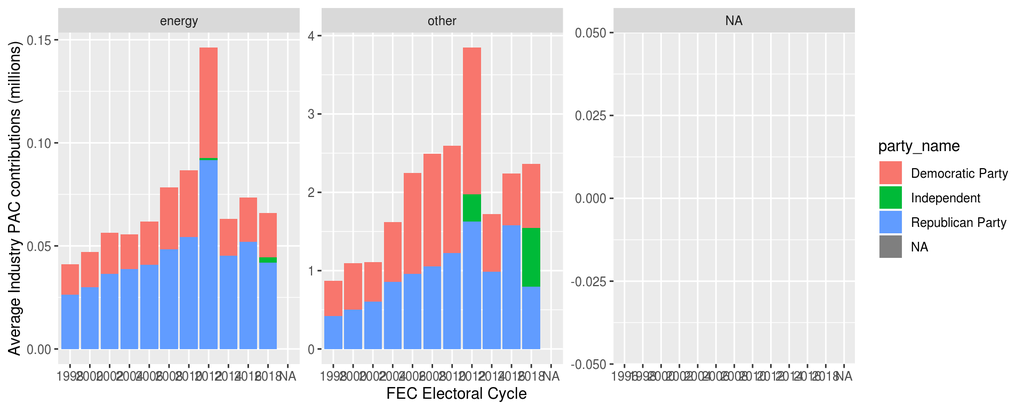

```r
# inspect coverage
d1 %>%
  group_by(cycle, icpsr, party_name, industry) %>%
  summarise(total = sum(amounts, na.rm = TRUE)/1000000) %>%
  ungroup() %>%
  group_by(cycle, party_name, industry) %>%
  summarise(mean = mean(total)) %>% # filter(cycle >2008, industry == "energy") %>% arrange(party_name)
  ggplot() +
  aes(x = factor(cycle), y = mean, fill = party_name) +
  geom_col() +
  facet_wrap("industry", scales = "free") +
  labs(y = "Average Industry PAC contributions (millions)",
       x = "FEC Electoral Cycle")
```

# Save results

```r
pac_contributions <- d
save(pac_contributions, file = here("data/pac_contributions.Rdata"))

pac_amounts <- d1
save(pac_amounts, file = here("data/pac_amounts.Rdata"))
```